# Homework 6

Arlette Hall

2026-01-27

## Instructions

Answer the following questions and/or complete the exercises in RMarkdown. Please embed all of your code and push the final work to your repository. Your report should be organized, clean, and run free from errors. Remember, you must remove the `#` for any included code chunks to run.

## Load the tidyverse

```r
library("tidyverse")
library("janitor")
```

## Data

For this assignment, we will use data from a study on vertebrate community composition and impacts from defaunation in [Gabon, Africa](https://en.wikipedia.org/wiki/Gabon). One thing to notice is that the data include 24 separate transects. Each transect represents a path through different forest management areas.

Reference: Koerner SE, Poulsen JR, Blanchard EJ, Okouyi J, Clark CJ. Vertebrate community composition and diversity declines along a defaunation gradient radiating from rural villages in Gabon. *Journal of Applied Ecology*. 2016. A description of the variables is included inside the data folder.

**1. Load `IvindoData_DryadVersion.csv` and store it as a new object called `gabon`.**

```r
gabon <- read.csv("C:/Users/fluff/Desktop/BIS15L_W26_aehall/lab6/data/IvindoData_DryadVersion.csv")
```

**2. Use one or more of the summary functions you have learned to get an idea of the structure of the data.**

```r
str(gabon) #check structure of gabon dataset
```

```
## 'data.frame':    24 obs. of  26 variables:
##  $ TransectID             : int  1 2 2 3 4 5 6 7 8 9 ...
##  $ Distance               : num  7.14 17.31 18.32 20.85 15.95 ...
##  $ HuntCat                : chr  "Moderate" "None" "None" "None" ...
##  $ NumHouseholds          : int  54 54 29 29 29 29 29 54 25 73 ...
##  $ LandUse                : chr  "Park" "Park" "Park" "Logging" ...
##  $ Veg_Rich               : num  16.7 15.8 16.9 12.4 17.1 ...
##  $ Veg_Stems              : num  31.2 37.4 32.3 29.4 36 ...
##  $ Veg_liana              : num  5.78 13.25 4.75 9.78 13.25 ...
##  $ Veg_DBH                : num  49.6 34.6 42.8 36.6 41.5 ...
##  $ Veg_Canopy             : num  3.78 3.75 3.43 3.75 3.88 2.5 4 4 3 3.25 ...
##  $ Veg_Understory         : num  2.89 3.88 3 2.75 3.25 3 2.38 2.71 3.25 3.13 ...
##  $ RA_Apes                : num  1.87 0 4.49 12.93 0 ...
##  $ RA_Birds               : num  52.7 52.2 37.4 59.3 52.6 ...
##  $ RA_Elephant            : num  0 0.86 1.33 0.56 1 0 1.11 0.43 2.2 0 ...
##  $ RA_Monkeys             : num  38.6 28.5 41.8 19.9 41.3 ...
##  $ RA_Rodent              : num  4.22 6.04 1.06 3.66 2.52 1.83 3.1 1.26 4.37 6.31 ...
##  $ RA_Ungulate            : num  2.66 12.41 13.86 3.71 2.53 ...
##  $ Rich_AllSpecies        : int  22 20 22 19 20 22 23 19 19 19 ...
##  $ Evenness_AllSpecies    : num  0.793 0.773 0.74 0.681 0.811 0.786 0.818 0.757 0.773 0.668 ...
##  $ Diversity_AllSpecies   : num  2.45 2.31 2.29 2.01 2.43 ...
##  $ Rich_BirdSpecies       : int  11 10 11 8 8 10 11 11 11 9 ...
##  $ Evenness_BirdSpecies   : num  0.732 0.704 0.688 0.559 0.799 0.771 0.801 0.687 0.784 0.573 ...
##  $ Diversity_BirdSpecies  : num  1.76 1.62 1.65 1.16 1.66 ...
##  $ Rich_MammalSpecies     : int  11 10 11 11 12 12 12 8 8 10 ...
##  $ Evenness_MammalSpecies : num  0.736 0.705 0.65 0.619 0.736 0.694 0.776 0.79 0.821 0.783 ...
##  $ Diversity_MammalSpecies: num  1.76 1.62 1.56 1.48 1.83 ...
```

**3. Clean the data as necessary following the conventions from lab 6.**

```r
gabon <- clean_names(gabon)  #clean up variable names
names(gabon)  #check variable names
```

```
##  [1] "transect_id"              "distance"
##  [3] "hunt_cat"                 "num_households"
##  [5] "land_use"                 "veg_rich"
##  [7] "veg_stems"                "veg_liana"
##  [9] "veg_dbh"                  "veg_canopy"
## [11] "veg_understory"           "ra_apes"
## [13] "ra_birds"                 "ra_elephant"
## [15] "ra_monkeys"               "ra_rodent"
## [17] "ra_ungulate"              "rich_all_species"
## [19] "evenness_all_species"     "diversity_all_species"
## [21] "rich_bird_species"        "evenness_bird_species"
## [23] "diversity_bird_species"   "rich_mammal_species"
## [25] "evenness_mammal_species"  "diversity_mammal_species"
```

```r
gabon <- distinct(gabon)  #remove any repeat entries
```

**4. Use `mutate()` Change the variables `HuntCat`, `LandUse`, and `TransectID` to factors. Be sure to store the output as a new dataframe and use it for the remaining questions.**

```r
gabon2 <- gabon %>%  #change hunt_cat, land_use, transect_id to factors
  mutate(across(c(hunt_cat, land_use, transect_id), as.factor))

str(gabon2$hunt_cat)  #check work
```

```
##  Factor w/ 3 levels "High","Moderate",..: 2 3 3 3 3 3 3 3 1 1 ...
```

```r
str(gabon2$land_use)
```

```
##  Factor w/ 3 levels "Logging","Neither",..: 3 3 3 1 3 3 3 1 2 1 ...
```

```r
str(gabon2$transect_id)
```

```
##  Factor w/ 23 levels "1","2","3","4",..: 1 2 2 3 4 5 6 7 8 9 ...
```

**5. Make a plot that shows the number of transects for each land use type.**

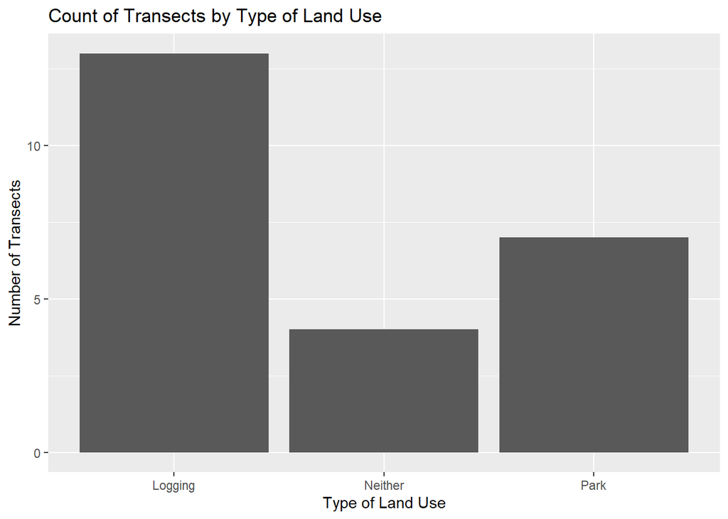

```r
ggplot(data=gabon2,
       mapping=aes(x=land_use))+
  geom_bar()+
  labs(x = "Type of Land Use", y = "Number of Transects", title = "Count of Transects by Type of Land Use")
```

**6. How does vegetation richness compare among land use types?**

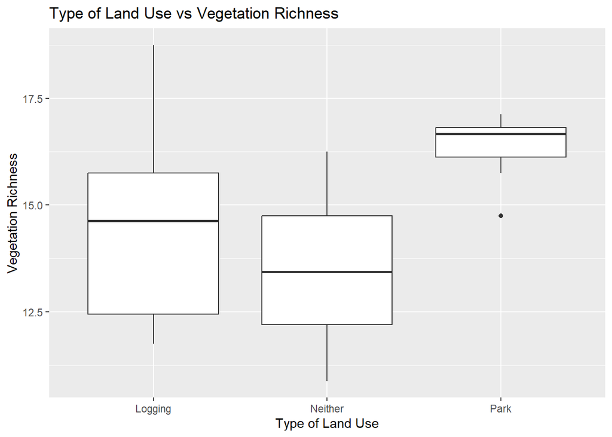

```r
ggplot(data=gabon2,
       mapping=aes(x=land_use, y=veg_rich))+
  geom_boxplot(na.rm=T)+
  labs(x = "Type of Land Use", y = "Vegetation Richness", title = "Type of Land Use vs Vegetation Richness")
```

```r
#National Parks have the greatest vegetation richness & the narrowest variation.
#Logging concessions have the widest variation in vegetation richness.
#Neither has the least vegetation richness.
```

**7. For which land use type (national parks, logging, or neither) is average all species diversity the greatest?**

```r
gabon_park <- gabon2 %>%
  filter(land_use == "Park")
mean(gabon_park$rich_all_species)
```

```
## [1] 21.85714
```

```r
gabon_log <- gabon2 %>%
  filter(land_use == "Logging")
mean(gabon_log$rich_all_species)
```

```
## [1] 19.61538
```

```r
gabon_neither <- gabon2 %>%
  filter(land_use == "Neither")
mean(gabon_neither$rich_all_species)
```

```
## [1] 19.25
```

```r
#National Parks have the greatest average all species diversity.
```

**8. Is there a relationship between vegetation richness and mammal species richness?**

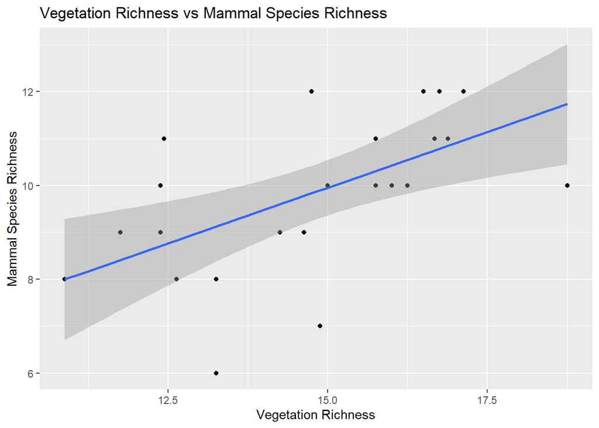

```r
ggplot(data=gabon2,
       mapping=aes(x=veg_rich, y=rich_mammal_species))+
  geom_point(na.rm=T)+
  geom_smooth(method=lm, se=T)+
  labs(x = "Vegetation Richness", y = "Mammal Species Richness", title = "Vegetation Richness vs Mammal Species Richness")
```

```r
#A possible slightly positive trend but it could be a correlation.
```

**9. Use `filter` to find all transects that have greater than 15 tree species or a breast height diameter between 50 and 60cm.**

```r
gabon2 %>%  #transects with more than 15 tree species
  filter(veg_rich > 15) %>%
  select(transect_id, veg_rich)
```

```
##    transect_id veg_rich
## 1            1    16.67
## 2            2    15.75
## 3            2    16.88
## 4            4    17.13
## 5            5    16.50
## 6            9    16.00
## 7           14    15.75
## 8           21    16.25
## 9           22    17.13
## 10          24    16.75
## 11          26    18.75
```

```r
gabon2 %>%  #transects with breast height diameter between 50 and 60 cm
  filter(veg_dbh >= 50 & veg_dbh <= 60) %>%
  select(transect_id, veg_dbh)
```

```
##   transect_id veg_dbh
## 1           6   51.22
## 2          14   52.12
## 3          15   54.77
## 4          17   57.71
## 5          21   50.36
```

**10.Which transects and land use types have more than 10 tree species and 10 mammal species? Use `arrange()` to sort by the number of tree species.**

```r
gabon2 %>%
  filter(veg_rich > 10 & rich_mammal_species > 10) %>%
  select(transect_id, land_use, veg_rich, rich_mammal_species) %>%
  arrange(veg_rich)
```

```
##   transect_id land_use veg_rich rich_mammal_species
## 1           3  Logging    12.44                  11
## 2           6     Park    14.75                  12
## 3          14  Logging    15.75                  11
## 4           5     Park    16.50                  12
## 5           1     Park    16.67                  11
## 6          24     Park    16.75                  12
## 7           2     Park    16.88                  11
## 8           4     Park    17.13                  12
## 9          22  Logging    17.13                  12
```

## Knit and Upload

Please knit your work as an .html file and upload to Canvas. Homework is due before the start of the next lab. No late work is accepted. Make sure to use the formatting conventions of RMarkdown to make your report neat and clean!